# Linear Model: Facial Appearance and Election Outcomes

#### Q-Q plot.

This plot is useful to check the normality of the error term.

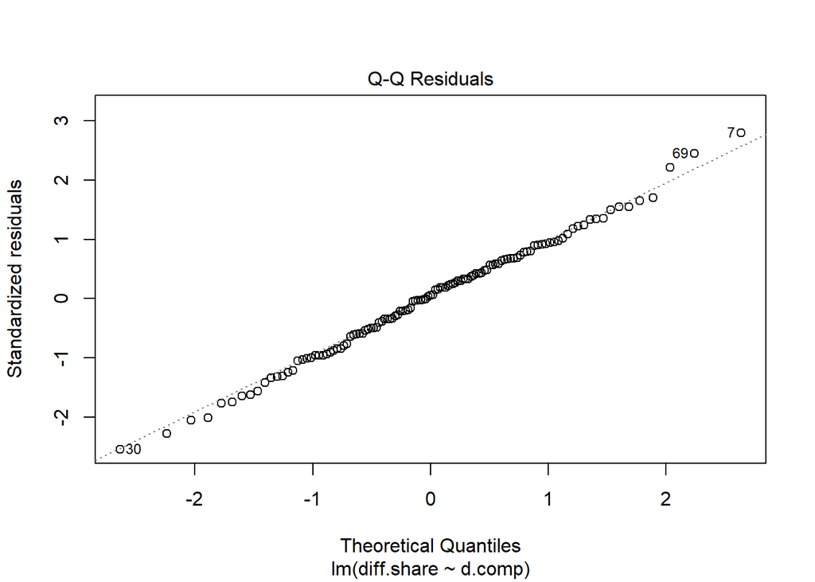

```r
plot(fit, which = 2)
```

The fact that the points in the Q-Q plot are reasonable aligned with the $x = y$, specially around $x = 0$, is evidence validating the normality assumption on the error term.

#### Standardized residuals vs. fitted values plot

It is similar to the first diagnostic plot, but now with the residuals standardized and transformed by a square root (of the absolute value). This makes the task of spotting heteroskedasticity about spotting for non-linearities.

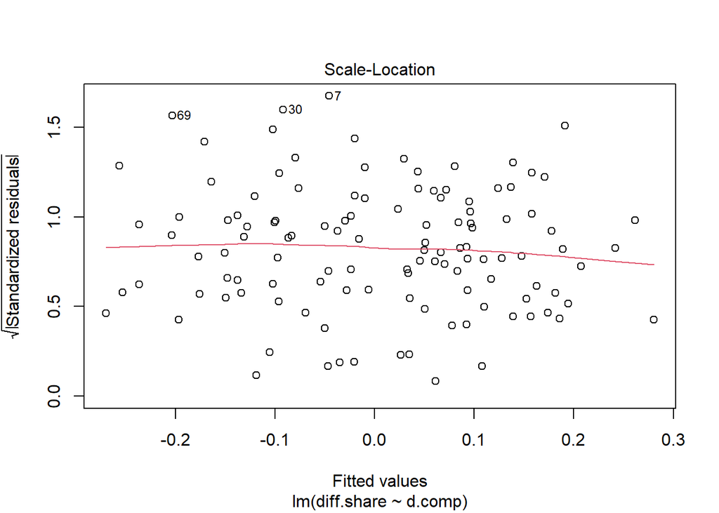

```r
plot(fit, which = 3)
```

# The summary of the linear regression

Many of the above-mentioned metrics can be spot as a single output of the linear-fit object `fit`, by using the function `summary()`.

```r
summary(fit)
```

```
##
## Call:
## lm(formula = diff.share ~ d.comp, data = face)
##
## Residuals:
##      Min       1Q   Median       3Q      Max
## -0.67487 -0.16600  0.01399  0.17741  0.74297
##
## Coefficients:
##             Estimate Std. Error t value Pr(>|t|)
## (Intercept) -0.31223    0.06596  -4.733 6.24e-06 ***
## d.comp       0.66038    0.12718   5.193 8.85e-07 ***
## ---
## Signif. codes:  0 '***' 0.001 '**' 0.01 '*' 0.05 '.' 0.1 ' ' 1
##
## Residual standard error: 0.2665 on 117 degrees of freedom
## Multiple R-squared:  0.1873, Adjusted R-squared:  0.1803
## F-statistic: 26.96 on 1 and 117 DF,  p-value: 8.854e-07
```

At the very top, the summary shows the formula used for the linear model, in this case `diff.share ~ d.comp`, followed by basic statistics about the residuals

The coefficient estimation and inference comes right below. The `Estimate` column shows the estimation of the coefficients, while the `Std. Error` displays the sample standard deviation associated to those estimators, and the `Pr(>|t|)` column shows their correspondent $p$-values (see next session).

Other useful metrics are those about the fitness of the model: `Residual standard error`, `R-squared`, and `Adjusted R-square`. Note that the $R^2$ coefficient coincides with the one calculated earlier. Recall that the Adjusted $R^2$, denoted by $\overline{R}^2$, is a deflated version of the $R^2$ that mitigates its inflation as more non-necessarily-significant regressors are added, making $\overline{R}^2$ a more reliable measure of fitness for multiple linear regression.

# Significance of the regressors.

Recall that the OLS estimator of the coefficients are random, meaning that, for a different dataset, the estimations change, thus carrying the randomness of the independent and dependent variables.

The question then arises:

- What if the constant coefficient $\beta_k$ is actually zero but the estimation $\widehat{\beta}_k$ is not, leading to a false sense of linearity between the regressor $X_k$ and the output $Y$?

This question is relevant since $\beta_k = 0$ means that the $k$th regressor is not relevant to explain the output $Y$. To answer this question, one needs tools of statistical inference. As a rule of thumb:

- If the **$p$-value** associated to the $k$th coefficient is lower than $\alpha\in (0,1)$, then we can assure that $\beta_k$ is statistically different from zero with a **confidence level** of $(1-\alpha)\times 100\%$, or with a **significance level** of $\alpha$.

This ‘’statistically significant’’ conclusion should be interpreted as follows:

- If $m$ datasets were handed to you and you were to perform $m$ different estimators $\widehat{\beta}_k$ and their respective $p$-values, roughly only $m\times\alpha$ times you where going to be wrong about the decision of considering $\beta_k = 0$.

Hence, one desires small values of $\alpha$ (tipically $0.1$, $0.05$, or $0.001$) to guarantee that considering $\beta_k = 0$, when actually $\beta_k \neq 0$, would be the wrong decision a small number of times, in the hope that our dataset lies in the right side.

In our case, the $p$-value related to the regressor `d.comp` is $8.85\times 10^{-7}$ (or `8.85e-07`), meaning that we can state:

- The competence measure for the Democratic candidate is statistically significant to explain the variability of the difference in votes received by the Democratic candidate vs Republicans candidates, with a confidence greater than $99\%$.

# Exercises

- **Exercise 1:** Repeat the whole analysis done in the notebook but using the competence measure for the Republican candidates `r.comp` to explain the difference in votes `face$diff.share`.

# Acknowledgement and Copyright

These notes are adapted from the book [Quantitative Social Science](https://press.princeton.edu/books/quantitative-social-science) by Kosuke Imai.

[^1]: Alexander Todorov, Anesu N. Mandisodza, Amir Goren, and Crystal C. Hall (2005) “Inferences of competence from faces predict election outcomes.” *Science*, vol. 308, no. 10 (June), pp. 1623–1626.